# Simulations for statistical testing

## Decision rules

By rejecting H0 iff \(p<\alpha\) we control the type I error rate (ie the false positive rate) at the \(\alpha\) level:

Let \(T_\alpha\) be the \((1-\alpha)\)-quantile of \(T\) under H0 (the critical value) \(\Rightarrow p<\alpha\) iff \(T_{obs} > T_\alpha\) (case of right unilateral tests) \[ \begin{align} \Rightarrow\mbox{Type I error rate }&=Pr(H0 \mbox{ rejected } | H0 \mbox{ holds })=Pr(p < \alpha | H0) \\ &= Pr( T_{obs} > T_\alpha | H0) = \alpha \end{align} \]

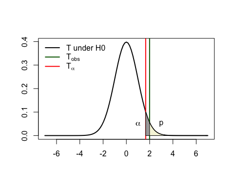

## Misconceptions about p-values

- p value is not the probability that H0 holds given the data. For this, a prior probability of H0 is needed: \[ Pr(H0|\mbox{data})=\frac{Pr(\mbox{data}|H0)\times Pr(H0)}{Pr(\mbox{data}|H0)\times Pr(H0)+Pr(\mbox{data}|H1)\times Pr(H1)} \]
- An alternative to frequentist p value is Bayes factor \(BF=Pr(\mbox{data}|H1)/Pr(\mbox{data}|H0)\): \[ \frac{Pr(H1|\mbox{data})}{Pr(H0|\mbox{data})}=BF\times\frac{Pr(H1)}{Pr(H0)} \]
- \(p<\alpha\) suggests there might be something in data, it is not a proof of scientific finding. What matters is the effect size
- use p values only to test well defined hypothesis
- do not forget confidence intervals
- controversial finding: published studies with \(p<\alpha\) are *often* not replicable (wait a few slides…)

References

- Nuzzo, R. (2014). Nature, 506(7487), 150-152.
- Senn, S. (2001). Journal of Epidemiology and Biostatistics, 6(2), 193-204.

## Statistical Power

|  | H0 not rejected | H0 rejected |
| --- | --- | --- |
| H0 true | \(1-\alpha\) | \(\alpha=\) type I error rate = significance level |
| H0 not true | \(\beta=\) type II error rate | \(1-\beta=\) Power |

\[ \begin{align} \mbox{Power } &= Pr(H0 \mbox{ rejected } | H1 \mbox{ holds}) \\ &= Pr(T > T_{\alpha}| H1 \mbox{ holds}) \end{align} \]

henceforth:

- Power is a function of \(\alpha\)
- In order to compute the test power one must know the distribution of \(T\) under H1

## Back to the example

What is the power of our t-test to reject H0 at confidence level \(\alpha=0.01\) if \(\mu_0-\mu_1=0.28\) (H1)?

Under H1, \(T\) follows a t-distribution with non-centrality \(\frac{\mu_0-\mu_1}{\sigma\sqrt{1/n_0+1/n_1}}\)

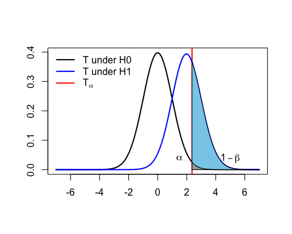

```r
m0=mean(Mvalue[Outcome==0]); m1=mean(Mvalue[Outcome==1])
ncp=ncp=(m0-m1)/s/sqrt(1/50+1/50)
pw=pt(q=qt(p=1-0.01,df=98),df=98,ncp=ncp,lower.tail=FALSE)
unlist(list(Power=pw))
```

```
##    Power
## 0.359906
```

Or equivalently, using the R built-in function:

```r
power.t.test(n=50,delta=0.28,alternative='one.sided',type='two.sample',sig.level=0.01,sd=sd(Mvalue))
```

```
##
##      Two-sample t test power calculation
##
##               n = 50
##           delta = 0.28
##              sd = 0.7043647
##       sig.level = 0.01
##           power = 0.3571275
##     alternative = one.sided
##
## NOTE: n is number in *each* group
```

## The replicability crisis

- Positive findings are often not replicable in subsequent studies (in all fields)
- This can happen when initial studies are underpowered. To see why, consider the false-positive report probability (FPRP):

\[ \begin{align} FPRP = Pr(H0 | p < \alpha) = & \frac{Pr(p<\alpha|H0)\times Pr(H0)}{Pr(p<\alpha|H0)\times Pr(H0)+Pr(p<\alpha|H1)\times Pr(H1)} \\ = & \frac{\alpha Pr(H0)}{\alpha Pr(H0) + (1-\beta) Pr(H1)} \end{align} \] \(\Rightarrow\) the FPRP increases for lower \(\beta\)s

References

- Wacholder,S. (2004). J. Natl Cancer Inst. 96, 434-442
- Goodman, S. N. (1992). Stat. Med., 11(7), 875-879.

## Probability that H0 is true if test is positive

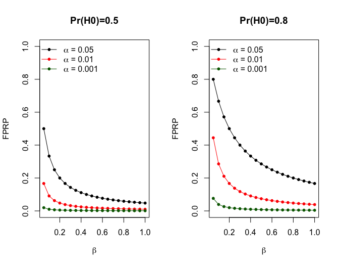

## Testing with simulations: an overview

## Simulations are useful when…

…the distribution of \(T\) under H0 is not known (analytic derivation of its densities and CDF not possible, large sample approximations not available or not applicable) but it is possible to sample it  
\(\Rightarrow\) we can calculate the empirical p value:

1. simulate \(N\) realizations of \(T\) under H0:
2. estimate p with \[ \hat{p} = \frac{\#\{ \mbox{ H0 } T \mbox{ realizations } > T_{obs}\}}{N} \] (change \(>\) for bilateral and unilateral left tests…) ## and when..

…the distribution of \(T\) under H1 is not known but it is possible to sample it  
\(\Rightarrow\) we can calculate the empirical power:

1. simulate \(N\) realizations of \(T\) under H1
2. estimate power with \[ \hat{\mbox{power}} = \frac{\#\{ \mbox{ H1 } T \mbox{ realizations } > T_\alpha\}}{N} \] where \(T_\alpha\) is the \((1-\alpha)\)-quantile of \(T\) under H0. If the distribution of T under H0 is not known, one can sample T under H0 and take the \((1-\alpha)\)-quantile.

## Why it works

**Law of large numbers**

If \(Y_1,\ldots,Y_N\) are an i.i.d. sample from distribution \(G\) then \[ \frac{1}{N}\sum_{i=1}^NY_i \xrightarrow{P} E[Y] \]

In our case we have:

- \(T_1\ldots,T_N\) are an i.i.d. sample from the distribution \(G\) of \(T\)
- The indicator variables \(\mathbb{1}_{T_1>T_{obs}},\ldots,\mathbb{1}_{T_N>T_{obs}}\) are an i.i.d. sample from a Bernoulli distribution whose expected value is the p value
- Hence: \[ \frac{1}{N}\sum_{i=1}^N \mathbb{1}_{T_i>T_{obs}} = \frac{\#\{ T \mbox{ realizations } > T_{obs}\}}{N} \xrightarrow{P} p \]

## (Silly) application to our example: empirical p

```r
Tsample0=rt(10000,df=98)
em_p=mean(Tsample0>Tobs)
unlist(list(p=p, empirical_p=em_p))
```

```
##           p empirical_p
##  0.02440159  0.02490000
```

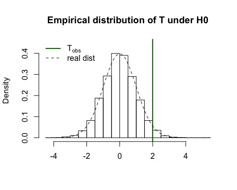

## (Silly) application: empirical power

```r
Tsample1=rt(10000,df=98,ncp=ncp)
Ta_em=quantile(Tsample0,probs=1-0.01)
em_pw=mean(Tsample1>Ta_em)
unlist(list(power=pw, empirical_power=em_pw))
```

```
##           power empirical_power
##        0.359906        0.361100
```

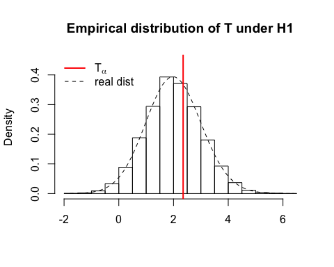

## Data replicates

Simulations are particularly useful for non-parametric tests (\(\neq\) previous example).

In this case, drawing a sample of the statistic under a given hypothesis requires two steps (Monte Carlo simulations):

- simulate \(N\) data replicates according to the hypothesis
- for each replicate \(i\), calculate the statistic realization \(T_i\)

Then p value and power are estimated as above.

## Focus on permutation-like methods

In the following we focus on ways of generating data replicates for testing whether two groups (eg cases vs controls) are the same:

1. Empirical p values through permutations (classic)
2. Empirical power through
   - Monte Carlo simulations (classic)
   - Weighted permutations (more original)

## Simulations for case/control testing: empirical p values

## Empirical p values trhough permutations

- Suppose we have observations \(x_1,\ldots,x_{n_0}\sim F_1\) for controls and observations \(y_1,\ldots,y_{n_1}\sim F_2\) for cases
- We want to test \[ \mbox{H0: } F_1=F_2\; \mbox{ versus }\; \mbox{ H1: }F_1\neq F_2 \] (case-control association can be seen as a particular case)
- Let \(T\) be our statistics, eg \(T=|\bar{x}-\bar{y}|\)

Key fact: H0 is equivalent to say that *the observations are independent from the case/control status*  
\(\Rightarrow\) we can sample the data distribution under H0 simply by shuffling the case control status: each permutation is a data replicate

## Example

Back to the Mvalue example with \(T=\bar{M}_{controls}-\bar{M}_{cases}\)

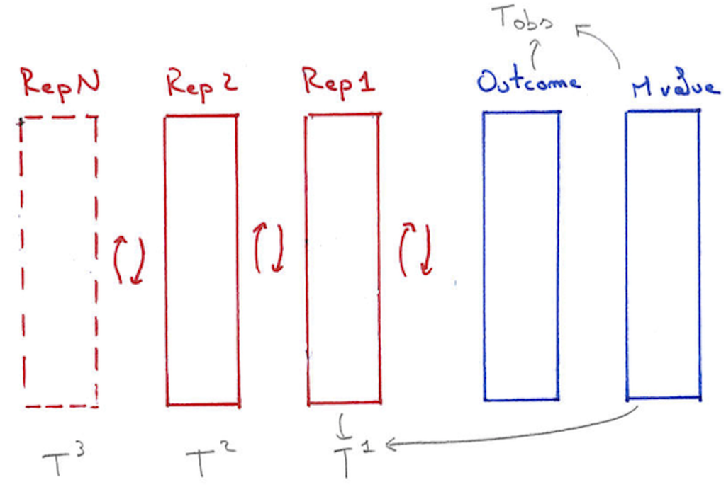

```r
tobs=abs(mean(Mvalue[Outcome==0])-mean(Mvalue[Outcome==1]))
one.perm=function(x,y){
  perm=sample(x)
  abs(mean(y[perm==0])-mean(y[perm==1]))
}
N=10000
t=replicate(N, one.perm(Outcome,Mvalue))
pp=mean(t>tobs)
unlist(list(p_permutation=pp))
```

```
## p_permutation
##        0.0517
```

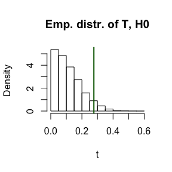

## Remarks

- Which N? We can compute a CI for p in the usual way:

```r
c(pp-1.96*sqrt(p*(1-p)/N),pp+1.96*sqrt(p*(1-p)/N))
```

```
## [1] 0.04867587 0.05472413
```

- Be careful that the smallest possible p is \(1/N\) \(\Rightarrow\) \(N\) must be very large in multiple testing
- Useful strategy: start with relatively small \(N\) and increase to large numbers only if p is small and you need more precision
- It is a good idea to store all data replicates in a data frame, one replicate per column and then use,

```r
apply(replicates,2,function_for_stat)
```

- Important for the following: permutations preserve the fixed number of cases and controls!

## A more interesting application: minimum p value

- Suppose we want to test case/control association with a block of 10 SNPs.
- We can start by doing a Fisher exact test for each individual SNP, resulting in a p value \(p_i\), and then we take the min p value as our statistic: \[ T=\min_{j=1,\ldots,10} p_j \]
- We need to know the distribution of this statistic if we want to calculate a global p value!
- This is not a standard distribution, so we turn to permutations

## Example

Mock genotypic data for 10 SNPs, 250 cases and 250 controls

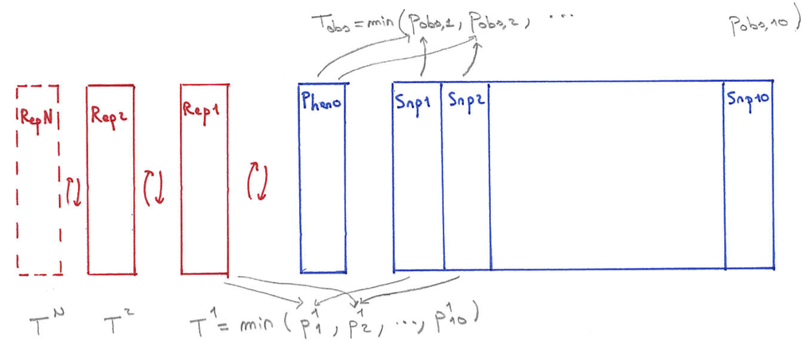

We load the data

```r
load('data/ex_snps.Rda')
head(cbind(pheno,geno))
```

```
##   pheno snp1 snp2 snp3 snp4 snp5 snp6 snp7 snp8 snp9 snp10
## 1     0    2    0    0    0    0    0    0    1    0     1
## 2     0    1    0    0    0    0    1    1    2    0     0
## 3     0    0    1    1    0    0    0    1    0    1     1
## 4     1    0    0    1    0    1    0    1    2    0     1
## 5     0    0    0    0    0    1    0    0    0    0     1
## 6     0    0    0    0    1    1    0    1    1    0     1
```

We calculate p values \(p_{obs,j}\) for individual SNPs and compute \(T_{obs}=\min_{j=1,\ldots,10} p_{obs,j}\)

```r
pvalues_obs=c(NA,10)
for(snp in 1:10) pvalues_obs[snp]=fisher.test(pheno,geno[,snp])$p
```

We calculate p values \(p_j\) for each permutation \(r\) and compute \(T^r=\min_{j=1,\ldots,10} p^r_j\)

```r
T_obs=min(pvalues_obs)
replicates0=matrix(NA,nrow=500,ncol=1000) #stores one permutation per column for later use
pvalues0=matrix(NA,nrow=10,ncol=1000) #stores the SNP p values in columns, one per replicate
for(repl in 1:1000){
  perm=sample(pheno)
  replicates0[,repl]=perm
  for(snp in 1:10){
  pvalues0[snp,repl]=fisher.test(perm,geno[,snp])$p
  }
}
T_sample0=apply(pvalues0,2,min)
```

At last we calculate the empirical p value for \(T\) as \[ \frac{\# \{T^r < T_{obs}\}}{\# \mbox{ replicates}} \]

```r
mean(T_sample0<T_obs)
```

```
## [1] 0.009
```

## Simulations for case/control testing: empirical power

## Empirical power with a focus on large scale association studies

- Apart from a few simple situations (eg t-test, \(\chi^2\)-test…), the distribution of the test statistics \(T\) under H1 is not known, neither exactly nor asymptotically
- This is typical of multi markers methods for GWAS and other large scale genetic studies
- In these cases power is usually estimated by analysing many data replicates under H1
- In association studies H1 is the assumption of a disease model ie a penetrance function
- In symbols:
  - \(n_1=\) number of cases, \(n_0\) number of controls, \(n=n_0+n_1\)
  - \(X^j_i=\) genotype of individual \(i\) for market \(j\)
  - \(Y_i=\) phenotype (case/control) of \(i\)
  - H1: penetrance function \(\pi_i=Pr(Y_i=1|X_i)\)

## Which simulations under H1?

- Important constraint: simulations should all preserve the fixed number of cases and control
- Naif protocol:
  - draw individual phenotypes given their real genotypes by sampling \(Y_i|X_i\sim\mathcal{B}(\pi_i)\)
  - Problem: \(\pi_i\) is small \(\Rightarrow\) we end up with very few cases!
- Two alternative approaches:
  1. Simulation of both genotypes and phenotypes for a very large population:
     - Simulate \(m\) genotypic datasets, with \(m>>n\)
     - For each individual of this large population draw \(Y_i|X_i\) as above
     - Hope that \(m\) is large enough to have enough cases
  2. Simulation of genotypes given fixed phenotypes: \(X_i|Y_i\) has a multinomial distribution with parameter \(\propto \pi_i\times Pr(X_i)\). Approach implemented in HAPGEN [Zu, S. (2011). Bioinformatics, 27(16), 2304-2305]
- Common problem: a genotypic model is needed! Not a problem for independent markers but what about mimicking LD patterns?

## Problems with first approach (i)

Slow, requires a lot of memory

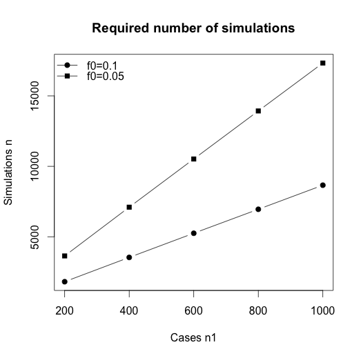

Ref: Alarcon, F. and Perduca, V. Work in progress

## Problems with first approach (ii)

Attention: raising the disease prevalence is not an option as this will bias the power estimates

[figure not shown]

Ref: Perduca, V. (2012). Hum Hered, 73:95-104.

## A possible solution: weighted permutations

- **waffect** is a recently introduced algorithm that affects the phenotype of each individual
  - conditionally on genotype
  - according to the fixed disease model
  - in a way that preserves the fixed number of cases
- Advantages:
  - fast, only phenotypes are simulated
  - one can use original genotypic datasets
  - R package available
  - One simple function, only input are the probabilities \(\pi_i\)

Ref: Perduca, V. (2012). Hum Hered, 73:95-104.

## How it works

- waffect is based on a Belief Propagation algorithm for a simple HMM-like graphical model
- idea is to sample recursively phenotypes. Let \(Z_i\) the number of cases affected for individuals \(1,\ldots,i\), then the steps are
  - draw \(Y_1\) conditionally on the fixed total number of cases \(Z_n=n_1\)
  - draw \(Y_2\) conditionnally on \(Z_1\) and \(Z_n=n_1\)
  - drawn \(Y_3\) conditionally on \(Z_2\) and \(Z_n=n_1\)
  - etc

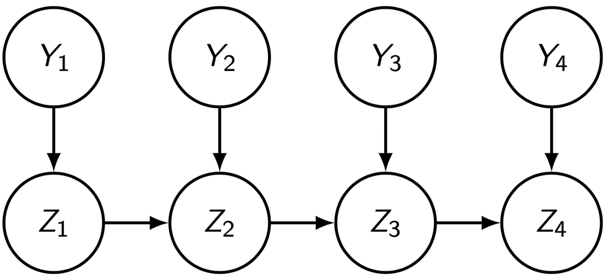

## Example

- We calculate the empirical power of the test looking for a signal in the 10 SNPs by simulating phenotypes under H1 using waffect
- Fr H1 we take an additive disease model with prevalence \(f_0=0.1\) and OR \(=1.6\) on SNP 8: \[ \pi_i= \frac{1}{1+\exp(-\log(f_0)-\log(OR)\times snp_8)} \]
- Recall that
  - \(T=\min_{j=1,\ldots,10} p_j\)
  - \(\hat{\mbox{power}} = \frac{\#\{ \mbox{ H1 } T \mbox{ realizations } > T_\alpha\}}{N}\).

We first define a disease model for H1 and calculate \(T_\alpha\) using the sample of \(T\) under H0 previously calculated

```r
pi=1/(1+exp(-log(0.1)-log(1.6)*geno[,8]))
threshold=quantile(T_sample0,probs=0.05)
```

We use waffect to simulate replicates with 250 cases and 250 controls according to \(\pi_i\)

```r
require(waffect)
pvalues1=matrix(NA,nrow=10,ncol=1000) #stores the SNP p values in columns, one per replicate
for(repl in 1:1000){
  wperm=waffect(prob=pi,count=250,label=c(1,0))
  for(snp in 1:10){
    pvalues1[snp,repl]=fisher.test(wperm,geno[,snp])$p
  }
}
T_sample1=apply(pvalues1,2,min)
```

We estimate the power

```r
mean(T_sample1<threshold)
```

```
## [1] 0.605
```

## Applications to the multiple testing problem

## Family Wise Error Rate

- Standard individual marker approaches for GWAS consist in testing for each SNP \[ \mbox{H0}_j: \mbox{ SNP}_j \mbox{ not associated vs H1}_j: \mbox{SNP}_j \mbox{ associated } \]
- If there are \(p\) SNPs and each test is done at threshold \(\alpha\), expect \(p\times \alpha\) false positives (type I errors) when no SNP is associated. Eg \(p=10^6\) and \(\alpha=0.05 \Rightarrow\) in average 50000 false positives!

* The Family Wise Error Rate (FWER) is the probability of having at least one false positive when H0 is true for all \(p\) tests.

- If all tests are independent (not realistic because of LD): \[ FWER = Pr(\exists ~1 \leq j \leq p \mbox{ s.t. } H0_{j} \mbox{ rejected } | \forall~ j\, H0_{j} \mbox{ holds}) = 1-(1-\alpha)^p \]
- If the test are dependent: FWER \(<1-(1-\alpha)^p\)
- We avoid type I error rate inflation by doing each test at a level \(\alpha\) such that the FWER is \(\leq \alpha'\) where \(\alpha'\) is a fixed threshold, for instance \(\alpha'=0.05\)

## Bonferroni correction

If there are \(p\) SNPs, do each test at the threshold \[ \alpha=\frac{\alpha'}{p}, \] then FWER \(\leq \alpha\).

**Proof.**

\[ \begin{align} \mbox{FWER} & = Pr(\bigcup_{j=1}^p(H0_j \mbox{ rejected }|H0_j \mbox{ holds})\\ & \leq \sum_{j=1}^p Pr(H0_j \mbox{ rejected }|H0_j \mbox{ holds}) \\ & = \sum_{j=1}^p \frac{\alpha'}{p} \\ & = \alpha'. \end{align} \]

## The problem with Bonferroni correction

- \(\frac{\alpha'}{p}\) is very small \(\Rightarrow\) power loss
- Loss in power is even more important if tests are dependent: if there are only \(q\) truly independent tests out of \(p\), ideally one would need to take \[ \frac{\alpha'}{q} > \frac{\alpha'}{p} \]

## Example: independent SNPs

```r
mean(apply(pvalues0,2,min)<0.05/10)
```

```
## [1] 0.046
```

## Example: correlated SNPs

Same analysis with 10 correlated SNPs:

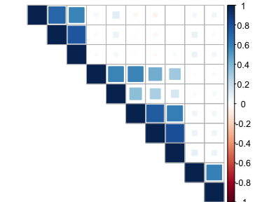

```r
load('data/ex_snps_d.Rda')
require(corrplot); corrplot(corr=cor(geno_d),method='square',type='upper',tl.pos='n')
```

```r
pvalues0_d=matrix(NA,nrow=10,ncol=1000) #stores the SNP p values in columns, one per replicate
for(repl in 1:1000){
  perm=sample(pheno)
  for(SNP in 1:10){
    pvalues0_d[SNP,repl]=fisher.test(perm,geno_d[,SNP])$p
  }
}
T_sample0_d=apply(pvalues0_d,2,min)
```

This time the FWER estimate is lower than \(\alpha'=0.05\):

```r
mean(apply(pvalues0_d,2,min)<0.05/10)
```

```
## [1] 0.033
```

## Several approaches to overcome the problem

- Several methods have been proposed to choose \(q\):
  - \(q=\) number of LD blocks
  - eigenvalues of the correlation matrix of the SNP allele counts
- Several studies based on HapMap data suggested a threshold of \(5\times 10^{-8}\) for European studies
- In the following we discuss an alternative based on permutations

Ref. Sham, P. C. (2014). Nat. Rev. Genet, 15(5), 335-346.

## Permutation procedure for FWER control

- Obtain the empirical distribution of \(T=\min_{j=1,\ldots,10} p_j\):

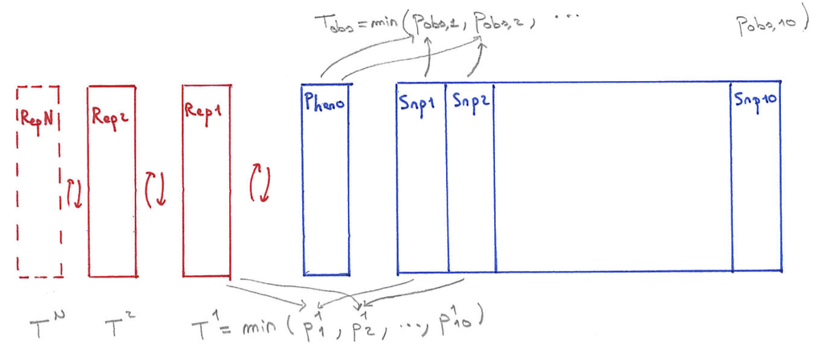

- Take the \(\alpha'\)-quantile \(T_{\alpha'}\)
- Test each SNP at the threshold \(T_{\alpha'}\)

## Why it works

**Proof.** \[ \begin{align} FWER & = Pr_{H0}(\exists j \mbox{ s.t. } H0_{j} \mbox{ rejected }) \\ & = Pr_{H0}(\exists j \mbox{ s.t. } p_{obs,j}< T_{\alpha'}) \\ & = Pr_{H0}(\min_j p_{obs,j} < T_\alpha') \\ & = Pr_{H0}(T<T_{\alpha'})=\alpha'. \end{align} \]

Equivalently, define for each SNP \(j\) the empirical adjusted p value \[ p^{adj}_j=\frac{r+1}{N+1} \] where \(r\) is the number of \(T^r\) smaller than \(p_{obs,j}\), and reject H0\(_j\) if \(p^{adj}_j<\alpha'\)

## Example: back to the 10 correlated SNPs

We compute \(T_{\alpha'}\)

```r
Tap=quantile(T_sample0_d,probs = 0.05)
unlist(list(threshold_perm=Tap))
```

```
## threshold_perm.5%
##       0.006982321
```

The estimate of the FWER is \(\alpha'=0.05\)

```r
mean(apply(pvalues0_d,2,min)<Tap)
```

```
## [1] 0.05
```